# Корреспондентный анализ и анализ главных компонент

## Корреспондентрый анализ и анализ главных компонент

- Сложности при анализе видового состава сообществ при помощи анализа главных компонент
  - Анализ сырых данных
  - Трансформация Хеллингера
  - Расстояние хорды
- Корреспондентный анализ
  - Анализ таблиц сопряженности, хи-квадрат
  - Оси в корреспондентном анализе
  - Интерпретация графиков в корреспондентном анализе

### Вы сможете

- Избавляться от “эффекта подковы” в анализе главных компонент при помощи трансформаций данных
- Проводить корреспондентный анализ таблиц сопряженности
- Объяснить, что именно означает взаиморасположение точек объектов и переменных на графиках результатов корреспондентного анализа
- Интерпретировать графики результатов корреспондентного анализа

## Анализ видового состава сообществ. Трансформации данных

## Пример: Птицы в лесах Австралии

Обилие 102 видов птиц в 37 сайтах в юго-восточной Австралии (Mac Nally, 1989; данные из Quinn, Keough, 2002). Можно ли описать отношения между сайтами небольшим числом главных компонент?

```r
library(readxl)
birds <- read_excel(path = "data/macnally.xlsx")
str(birds)
```

```
## Classes 'tbl_df', 'tbl' and 'data.frame':    37 obs. of  104 variables:
##  $ SITE    : chr  "Reedy Lake" "Pearcedale" "Warneet" "Cranbourne" ...
##  $ HABITAT : chr  "Mixed" "Gippsland Ma" "Gippsland Ma" "Gippsland Ma" ...
##  $ V1GST   : num  3.4 3.4 8.4 3 5.6 8.1 8.3 4.6 3.2 4.6 ...
##  $ V2EYR   : num  0 9.2 3.8 5 5.6 4.1 7.1 5.3 5.2 1.2 ...
##  $ V3GF    : num  0 0 0.7 0 12.9 10.9 6.9 11.1 8.3 4.6 ...
##  $ V4BTH   : num  0 0 2.8 5 12.2 24.5 29.1 28.2 18.2 6.5 ...
##  $ V5GWH   : num  0 0 0 2 9.5 5.6 4.2 3.9 3.8 2.3 ...
##  $ V6WTTR  : num  0 0 0 0 2.1 6.7 2 6.5 4.2 5.2 ...
##  $ V7WEHE  : num  0 0 10.7 3 7.9 9.4 7.1 2.6 2.8 0.6 ...
##  $ V8WNHE  : num  11.9 11.5 12.3 10 28.6 6.7 27.4 10.9 9 3.6 ...
##  $ V9SFW   : num  0.4 8.3 4.9 6.9 9.2 0 13.1 3.1 3.8 3.8 ...
##  $ V10WBSW : num  0 12.6 10.7 12 5 8.9 2.8 8.6 5.6 3 ...
##  $ V11CR   : num  1.1 0 0 0 19.1 12.1 0 9.3 14.1 7.5 ...
##  $ V12LK   : num  3.8 0.5 1.9 2 3.6 6.7 2.8 3.8 3.2 2.4 ...
```

[output cut: 86 more lines]

```r
# названия переменных
colnames(birds)
```

```
##   [1] "SITE"     "HABITAT"  "V1GST"    "V2EYR"    "V3GF"
##   [6] "V4BTH"    "V5GWH"    "V6WTTR"   "V7WEHE"   "V8WNHE"
##  [11] "V9SFW"    "V10WBSW"  "V11CR"    "V12LK"    "V13RWB"
##  [16] "V14AUR"   "V15STTH"  "V16LR"    "V17WPHE"  "V18YTH"
##  [21] "V19ER"    "V20PCU"   "V21ESP"   "V22SCR"   "V23RBFT"
##  [26] "V24BFCS"  "V25WAG"   "V26WWCH"  "V27NHHE"  "V28VS"
##  [31] "V29CST"   "V30BTR"   "V31AMAG"  "V32SCC"   "V33RWH"
##  [36] "V34WSW"   "V35STP"   "V36YFHE"  "V37WHIP"  "V38GAL"
##  [41] "V39FHE"   "V40BRTH"  "V41SPP"   "V42SIL"   "V43GCU"
##  [46] "V44MUSK"  "V45MGLK"  "V46BHHE"  "V47RFC"   "V48YTBC"
##  [51] "V49LYRE"  "V50CHE"   "V51OWH"   "V52TRM"   "V53MB"
##  [56] "V54STHR"  "V55LHE"   "V56FTC"   "V57PINK"  "V58OBO"
##  [61] "V59YR"    "V60LFB"   "V61SPW"   "V62RBTR"  "V63DWS"
##  [66] "V64BELL"  "V65LWB"   "V66CBW"   "V67GGC"   "V68PIL"
##  [71] "V69SKF"   "V70RSL"   "V71PDOV"  "V72CRP"   "V73JW"
##  [76] "V74BCHE"  "V75RCR"   "V76GBB"   "V77RRP"   "V78LLOR"
##  [81] "V79YTHE"  "V80RF"    "V81SHBC"  "V82AZKF"  "V83SFC"
##  [86] "V84YRTH"  "V85ROSE"  "V86BCOO"  "V87LFC"   "V88WG"
##  [91] "V89PCOO"  "V90WTG"   "V91NMIN"  "V92NFB"   "V93DB"
##  [96] "V94RBEE"  "V95HBC"   "V96DF"    "V97PCL"   "V98FLAME"
## [101] "V99WWT"   "V100WBWS" "V101LCOR" "V102KING"
```

```r
# имена переводим в нижний регистр
colnames(birds) <- tolower(colnames(birds))
# есть ли пропущенные значения
any(!complete.cases(birds))
```

```
## [1] FALSE
```

## Задание: Проведите анализ главных компонент

## Результаты анализа главных компонент

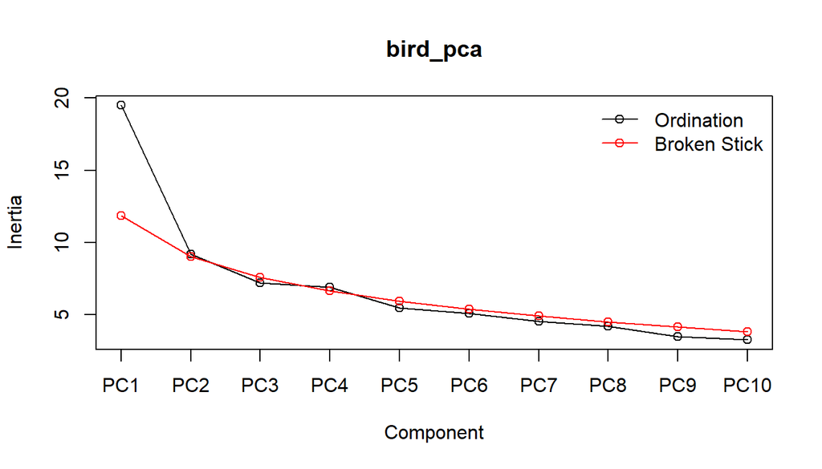

```r
library(vegan)
bird_pca <- rda(birds[ , -c(1, 2)], scale = TRUE)
# summary(bird_pca)
screeplot(bird_pca, type = "lines", bstick = TRUE) # график собственных чисел
```

- Первые две компоненты объясняют умеренное количество изменчивости

## Факторные нагрузки

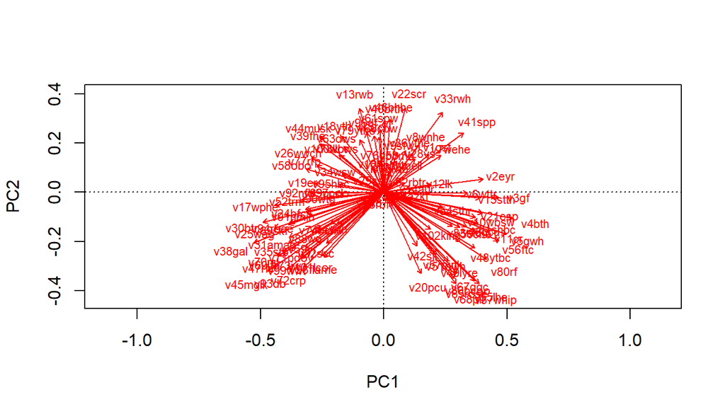

```r
biplot(bird_pca, display = "species", scaling = 2, type = "t")
```

- У многих переменных факторные нагрузки велики сразу на две оси. Это может быть неудобно.

## Обратите внимание, график в виде подковы!

Сайты 29 и 14 на самом деле расположены далеко друг от друга и мало похожи. Почему же они сближены на графике?

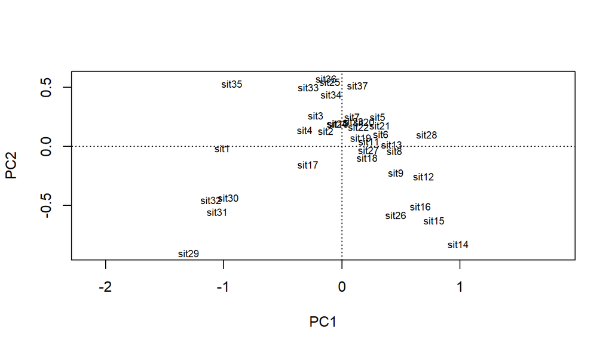

```r
biplot(bird_pca, display = "sites", scaling = 1) # биплот расстояний
```

- Так происходит от того, что завышены корреляции между переменными из-за большого числа нулей

## Чтобы исчез “эффект подковы” нужна трансформация исходных данных

- Стандартизация Хеллингера (Hellinger distance)
- хордальное расстояние (chord distance)

```r
birds_h <- decostand(birds[ , -c(1, 2)], method =  "hellinger") # Стандартизация Хеллингера
birds_ch <- decostand(birds[ , -c(1, 2)], method ="normalize") # Использование хордального расстояния
```

Задание: Выясните в чем суть этих преобразований.

## Задание: Проведите анализ главных компонент по трансформированным данным

Сравните долю дисперсии, объясненной первыми двумя компонентами с результатами анализа нетрансформированных данных.

- В каком случае объясненная дисперсия больше?

Сравните получившиеся ординации объектов.

- Исчез ли “эффект подковы” после трансформации?
- Изменилась ли группировка объектов?

## Анализ главных компонент

```r
bird_h_pca <- rda(birds_h)
summary(bird_h_pca)
```

```
##
## Call:
## rda(X = birds_h)
##
## Partitioning of variance:
##               Inertia Proportion
## Total           0.459          1
## Unconstrained   0.459          1
##
## Eigenvalues, and their contribution to the variance
##
## Importance of components:
##                         PC1    PC2    PC3    PC4    PC5    PC6    PC7
## Eigenvalue            0.136 0.0627 0.0534 0.0250 0.0199 0.0184 0.0152
## Proportion Explained  0.296 0.1365 0.1163 0.0545 0.0433 0.0400 0.0331
## Cumulative Proportion 0.296 0.4321 0.5484 0.6030 0.6463 0.6863 0.7194
##                          PC8    PC9   PC10    PC11    PC12    PC13
## Eigenvalue            0.0133 0.0109 0.0101 0.00893 0.00821 0.00812
## Proportion Explained  0.0288 0.0237 0.0220 0.01943 0.01787 0.01767
## Cumulative Proportion 0.7482 0.7720 0.7940 0.81343 0.83129 0.84896
##                          PC14    PC15    PC16    PC17   PC18    PC19
## Eigenvalue            0.00678 0.00653 0.00582 0.00547 0.0051 0.00479
## Proportion Explained  0.01476 0.01421 0.01268 0.01190 0.0111 0.01043
## Cumulative Proportion 0.86373 0.87794 0.89062 0.90252 0.9136 0.92405
##                          PC20    PC21    PC22    PC23    PC24    PC25
## Eigenvalue            0.00416 0.00362 0.00331 0.00311 0.00305 0.00241
## Proportion Explained  0.00906 0.00787 0.00720 0.00676 0.00664 0.00524
## Cumulative Proportion 0.93311 0.94098 0.94818 0.95495 0.96158 0.96682
##                          PC26    PC27    PC28    PC29    PC30    PC31
## Eigenvalue            0.00225 0.00199 0.00195 0.00161 0.00156 0.00135
## Proportion Explained  0.00490 0.00434 0.00423 0.00351 0.00339 0.00294
## Cumulative Proportion 0.97171 0.97605 0.98029 0.98380 0.98719 0.99012
##                          PC32    PC33     PC34     PC35     PC36
## Eigenvalue            0.00111 0.00108 0.000932 0.000782 0.000634
## Proportion Explained  0.00242 0.00235 0.002028 0.001702 0.001381
## Cumulative Proportion 0.99254 0.99489 0.996918 0.998619 1.000000
##
## Scaling 2 for species and site scores
## * Species are scaled proportional to eigenvalues
## * Sites are unscaled: weighted dispersion equal on all dimensions
```

[output cut: 135 more lines]

```
## sit23  0.11400 -0.25763  0.0686  0.59152  0.72330  0.69173
## sit24 -0.14998 -0.46352  0.3858 -0.00727 -0.61929  0.27836
## sit25  0.05981  0.54011  0.3263  0.30781 -0.01102  0.02930
## sit26  0.27883 -0.08798 -0.4861 -0.63367  0.25769 -0.35435
## sit27  0.27523 -0.00331 -0.2063 -0.15453 -0.39072  0.09646
## sit28  0.25232 -0.08262  0.1139  0.04586  0.17372  0.27189
## sit29 -0.68706  0.01015 -0.4806 -0.12015 -0.04966 -0.13932
## sit30 -0.55128  0.33655 -0.4290  0.57901  0.15766 -0.00388
## sit31 -0.64349  0.28274 -0.5421  0.34944  0.24431 -0.15845
## sit32 -0.76249 -0.00912 -0.4634 -0.02940  0.08322 -0.11965
## sit33 -0.08911  0.58574  0.6247 -0.34274  0.01183  0.45998
## sit34  0.02523  0.61068  0.4821 -0.08768 -0.04499  0.20477
## sit35 -0.42712  0.10664  0.4936 -0.67619 -0.10524  0.21471
## sit36  0.00381  0.60193  0.3724 -0.16703  0.17737 -0.00997
## sit37  0.14387  0.39760  0.2666  0.22621 -0.00269 -0.36827
```

## Собственные числа

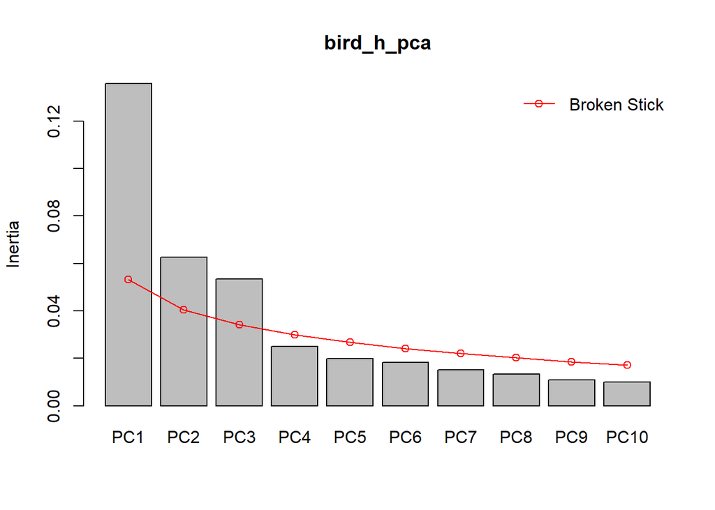

```r
screeplot(bird_h_pca, bstick = TRUE)
```

## Ординация до и после трансформации данных

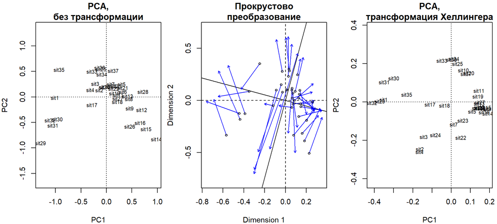

```r
op <- par(mfrow = c(1, 3), cex = 0.9, mar = c(4, 4, 2.5, 0.5))
biplot(bird_pca, display = "sites", scaling = 1, main = "PCA,\nбез трансформации")
plot(procrustes(bird_h_pca, bird_pca), main = "Прокрустово\nпреобразование")
biplot(bird_h_pca, display = "sites", scaling = 1, main = "PCA,\nтрансформация Хеллингера")
par(op)
```

## Для успешного применения анализа главных компонент нужно:

- Линейные связи между переменными (т.к. матрица корреляций или ковариаций)
- Исключить наблюдения, в которых есть пропущенные значения
- Если много нулей - трансформация данных
- Если очень много нулей - удалить такие переменные из анализа

## Пример: Крысы

Число грызунов разных видов в нескольких сайтах в южной Калифорнии (Bolger et al. 1997). Некоторые из этих сайтов оказались изолированы из-за урбанизации. Кроме того, несколько сайтов в исследовании из нефрагментированной местности.

```r
rats <- read.csv("data/bolger1.csv")
head(rats, 2)
```

```
##       SITE TYPE RRATTUS MMUSCUL PCALIFO PEREMIC RMEGALO NFUSCIP
## 1  Florida FRAG       0      13       3       1       1       2
## 2 Sandmark FRAG       0       1      57      65       9      16
##   NLEPIDA PFALLAX MCALIFO
## 1       0       0       0
## 2       8       2       3
```

```r
# имена переводим в нижний регистр
colnames(rats) <- tolower(colnames(rats))
# есть ли пропущенные значения
any(!complete.cases(rats))
```

```
## [1] FALSE
```

Данные из Quinn, Keough, 2002

## Задание: проведите анализ главных компонент

- Используйте хордальное расстояние
- Нарисуйте биплот расстояний

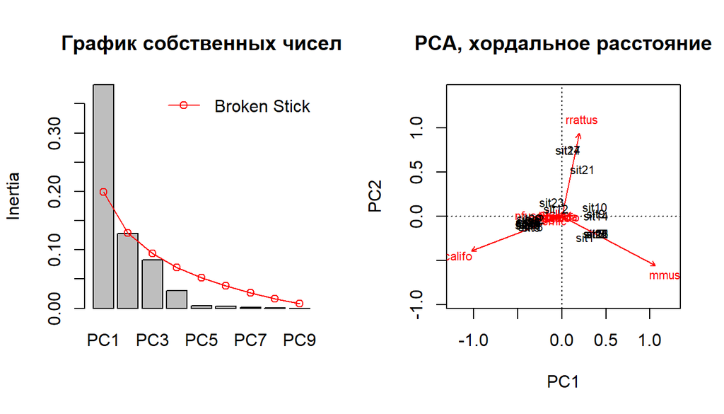

```r
rats_ch <- decostand(rats[ , -c(1, 2)], "norm") # chord distance
rats_ch_pca <- rda(rats_ch)
# summary(rats_ch_pca)
op <- par(mfrow = c(1, 2))
screeplot(rats_ch_pca, bstick = TRUE, main = "График собственных чисел")
biplot(rats_ch_pca, scaling = "symmetric", main = "PCA, хордальное расстояние")
par(op)
```

## Общие проблемы в двух примерах

1. Проявляется эффект подковы: непохожие объекты сближены на ординации.
2. Нет однзначной связи главных компонент и исходных признаков: трудно дать тратовку компонентам.
3. Преобразования не помогают избежать проблем.

**Выход:** 1. Перейти к nMDS и непрямым методам трактовки ординации. 2. Изменить логику анализа - отказаться от эвклидовой метрики, на которой основан PCA. Это позволяет сделать корреспондентный анализ таблиц сопряженности.

## Таблицы сопряженности

## Анализ таблиц сопряженности

Корреспондентный анализ был придуман для анализа сводных таблиц  
вроде этой:

| Горох | Желтый | Зеленый |
| --- | --- | --- |
| Гладкий | 99 | 42 |
| Морщинистый | 29 | 13 |

## Ожидаемые частоты

Таблица наблюдаемых частот

| Горох | Желтый | Зеленый | Сумма |
| --- | --- | --- | --- |
| Гладкий | **99** | 42 | **141** |
| Морщинистый | 29 | 13 | **42** |
| Сумма | **128** | **55** | **183** |

Ожидаемая частота (количество горошин) желтого и гладкого, если эти признаки независимы:

вероятность быть желтым \(\times\) вероятность быть гладким \(\times\) общее число горошин

\[\frac {141} {183} \times \frac{128} {183} \times 183 = \frac {141 \times 128} {183} = 98.6\]

## Можно посчитать ожидаемые частоты в каждой ячейке

Таблица наблюдаемых частот

| Горох | Желтый | Зеленый | Сумма |
| --- | --- | --- | --- |
| Гладкий | **99** | 42 | **141** |
| Морщинистый | 29 | 13 | **42** |
| Сумма | **128** | **55** | **183** |

Ожидаемая частота желтого и гладкого, если эти признаки независимы:

вероятность быть желтым \(\times\) вероятность быть гладким \(\times\) общее число горошин

\[\frac {141} {183} \times \frac{128} {183} \times 183 = \frac {141 \times 128} {183} = 98.6\]

Таблица ожидаемых частот

| Горох | Желтый | Зеленый |
| --- | --- | --- |
| Гладкий | 98.6 | 42.4 |
| Морщинистый | 29.4 | 12.6 |

## Проверяем гипотезу о независимости столбцов и строк

Таблица наблюдаемых частот

| Горох | Желтый | Зеленый | Сумма |
| --- | --- | --- | --- |
| Гладкий | **99** | 42 | **141** |
| Морщинистый | 29 | 13 | **42** |
| Сумма | **128** | **55** | **183** |

Таблица ожидаемых частот

| Горох | Желтый | Зеленый |
| --- | --- | --- |
| Гладкий | 98.6 | 42.4 |
| Морщинистый | 29.4 | 12.6 |

- Если столбцы и строки независимы, то наблюдаемые частоты не будут отличаться от ожидаемых
- Для каждой ячейки: \(\chi ^2 = \frac{(O - E)^2}{E}\)
- Общий хи-квадрат - это сумма по таблице \(\chi ^2 = \sum{\chi^2_{ij}}\)

## Корреспондентный анализ

**хи-квадрат - это мера независимости переменных (строк и столбцов)**

Корреспондентный анализ помогает визуализировать матрицу хи-квадратов, если переменных очень много

Механика похожа на анализ главных компонент (вернее, SVD - singular value decomposition)

Вместо столбцов и строк исходных данных получатся новые переменные - главные оси (principal axes)

## Свойства главных осей

- Главные оси независимы друг от друга (перпендикулярны)
- Каждая последующая объясняет меньше общей инерции (общего хи-квадрат, а не изменчивости!!!)
- Всего осей может быть не больше чем минимальное из этих значений: (число строк - 1), (число столбцов - 1)
- Первая ось - переменные, которые объясняют максимум зависимости строк от столбцов (значения которых сильнее всего отличаются от ожидаемых для данных объектов)
- Результаты изображаются в виде точечных графиков, похожих на биплоты (осторожно, scaling!)

## Корреспондентный анализ данных про крыс

```r
rats_ca <- cca(rats[ , -c(1, 2)])
summary(rats_ca)
```

```
##
## Call:
## cca(X = rats[, -c(1, 2)])
##
## Partitioning of scaled Chi-square:
##               Inertia Proportion
## Total            1.72          1
## Unconstrained    1.72          1
##
## Eigenvalues, and their contribution to the scaled Chi-square
##
## Importance of components:
##                         CA1   CA2   CA3    CA4    CA5    CA6    CA7
## Eigenvalue            0.746 0.459 0.288 0.1528 0.0357 0.0246 0.0113
## Proportion Explained  0.434 0.267 0.167 0.0889 0.0207 0.0143 0.0066
## Cumulative Proportion 0.434 0.701 0.868 0.9572 0.9780 0.9922 0.9988
##                           CA8
## Eigenvalue            0.00198
## Proportion Explained  0.00115
## Cumulative Proportion 1.00000
##
## Scaling 2 for species and site scores
## * Species are scaled proportional to eigenvalues
## * Sites are unscaled: weighted dispersion equal on all dimensions
##
##
## Species scores
##
##            CA1     CA2     CA3    CA4      CA5      CA6
## rrattus  2.606  5.2987 -0.0486 -0.205  0.03006 -0.00376
## mmuscul  2.290 -0.7746  0.0903  0.024 -0.00675  0.00285
## pcalifo -0.307  0.0508 -0.1341  0.355 -0.06321  0.01153
## peremic -0.413  0.0249  1.1472 -0.276 -0.02314 -0.17749
## rmegalo -0.316 -0.0421 -0.0691 -0.133  0.53280  0.21141
## nfuscip -0.273 -0.0766 -0.5245 -0.430  0.11879 -0.15344
## nlepida -0.447  0.0278  1.3563 -0.419 -0.04452  0.77173
## pfallax -0.275 -0.1031 -0.9429 -1.122 -0.42954  0.19305
## mcalifo -0.384 -0.0169  0.4457 -0.655 -0.74468  0.26151
##
##
```

[output cut: 16 more lines]

```
## sit14  3.1737  1.62001  0.19322 -0.2183  0.0689  0.0487
## sit15  3.0677 -1.68734  0.31393  0.1569 -0.1892  0.1160
## sit16  3.0677 -1.68734  0.31393  0.1569 -0.1892  0.1160
## sit17  3.4919 11.54204 -0.16891 -1.3437  0.8429 -0.1529
## sit18 -0.3406  0.01023 -0.71108  0.9639  0.0853  0.6190
## sit19 -0.4115  0.11066 -0.46632  2.3236 -1.7724  0.4691
## sit20 -0.0383  1.21510 -0.29380  1.8356 -1.4830  0.1608
## sit21  3.3505  7.13225 -0.00796 -0.8435  0.4989 -0.0633
## sit22  3.0677 -1.68734  0.31393  0.1569 -0.1892  0.1160
## sit23 -0.3759 -0.16396 -1.80243 -3.2440  2.7029 -1.4193
## sit24  3.4919 11.54204 -0.16891 -1.3437  0.8429 -0.1529
## sit25  3.0677 -1.68734  0.31393  0.1569 -0.1892  0.1160
## sit26 -0.3948  0.00427 -1.05370  0.1571 -0.7555 -1.2184
## sit27 -0.4046  0.01155 -0.72691  0.5309  2.3656  1.0467
## sit28 -0.4196  0.08282 -0.20812  1.5516 -1.2535 -0.7311
```

## Сколько общей инерции объясняют первые две главных оси?

```r
eig <- eigenvals(rats_ca)
eig/sum(eig)*100
```

```
##  CA1  CA2  CA3  CA4  CA5  CA6  CA7  CA8
## 43.4 26.7 16.7  8.9  2.1  1.4  0.7  0.1
```

```r
cumsum(eig)/sum(eig)*100
```

```
##   CA1   CA2   CA3   CA4   CA5   CA6   CA7   CA8
##  43.4  70.1  86.8  95.7  97.8  99.2  99.9 100.0
```

## Сколько главных осей достаточно?

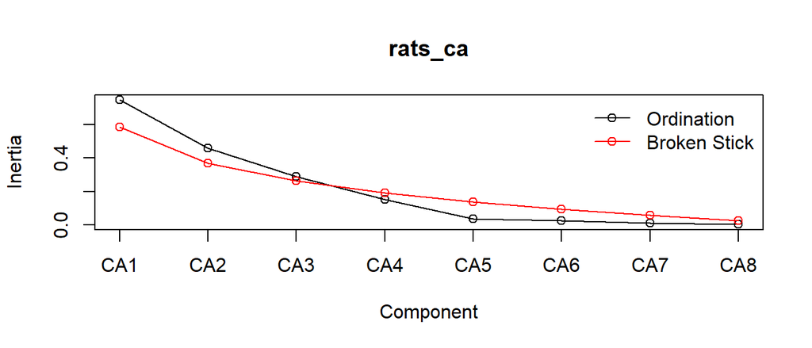

```r
screeplot(rats_ca, type = "lines", bstick = TRUE)
```

## Scaling

Разные варианты scaling не меняют порядок расположения, но меняют расстояния между объектами.

scaling 1 или “sites” (для графиков “объектов”) - расстояния между объектами пропорциональны хи-квадрату

scaling 2 или “species” (для графиков “переменных”) - расстояния между переменными пропорциональны хи-квадрату

scaling 3 или “symmetric” (компромиссный вариант) - нечто среднее между 1 и 2

## Как трактовать биплот в случае CA

- Если объект и переменная расположены рядом, то у этого объекта значение переменной выше ожидаемого при условии независимости объектов и переменных.
- Если объект и переменная расположены далеко, то у этого объекта значение переменной ниже ожидаемого.

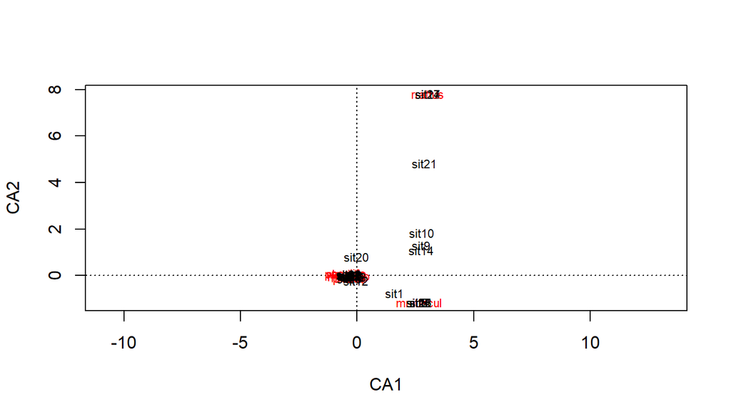

```r
plot(rats_ca, scaling = "sites")
```

## Создаем функцию, чтобы быстрее рисовать цветные графики

```r
col_ord_plot <- function(ord, scaling = 1, colvec = NULL, colfac, pch = 21, lab.cex = 1, leg.cex = 0.9, leg.pos = "bottom", ncol = 1, display.labs = TRUE, display.legend = TRUE, ...){
  if(is.null(colvec)){ # создаем вектор цветов
  ncolours <- length(levels(colfac))
  colvec <- rainbow(ncolours, s = 0.8, v = 0.9)
  }
  plot(ord, type = "n", scaling = scaling, ...) # пустой график
  # точки, раскрашенные по уровням фактора
  points(ord, display = "sites", scaling = scaling, pch = pch,
         col = colvec[colfac], bg = colvec[colfac], ...)
  if(display.labs == TRUE){ # подписи переменных
  text(ord, display = "species", scaling = scaling, cex = lab.cex)
  }
  if(display.legend == TRUE) { # легенда
  legend(x = leg.pos, legend = levels(colfac), bty = "n", pch = pch,
         col = colvec, pt.bg = colvec, cex = leg.cex, ncol = ncol)
  }
}
```

## Графики PCA и CA

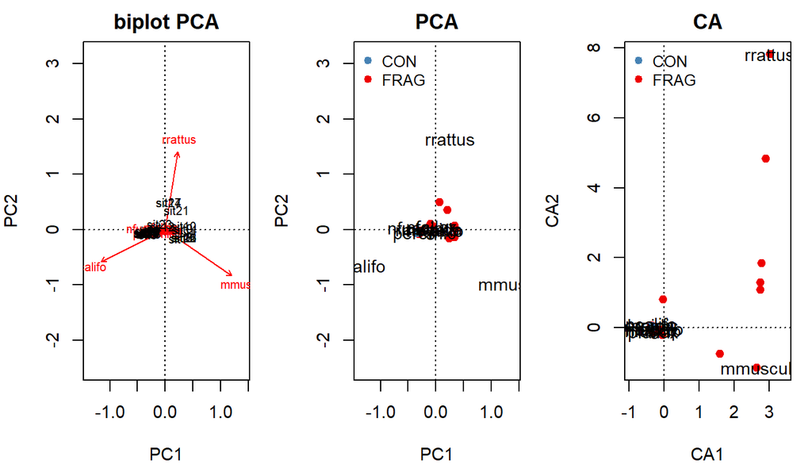

```r
op <- par(mfrow = c(1, 3), mar = c(4, 4, 2, 1), cex = 0.9)

biplot(rats_ch_pca, scaling = 1, main = "biplot PCA")

col_ord_plot(ord = rats_ch_pca, colvec = c("steelblue", "red2"),
             colfac = rats$type, leg.pos = "topleft", main = "PCA")
col_ord_plot(ord = rats_ca, colvec = c("steelblue", "red2"),
             colfac = rats$type, leg.pos = "topleft", main = "CA")
par(op)
```

## График CA

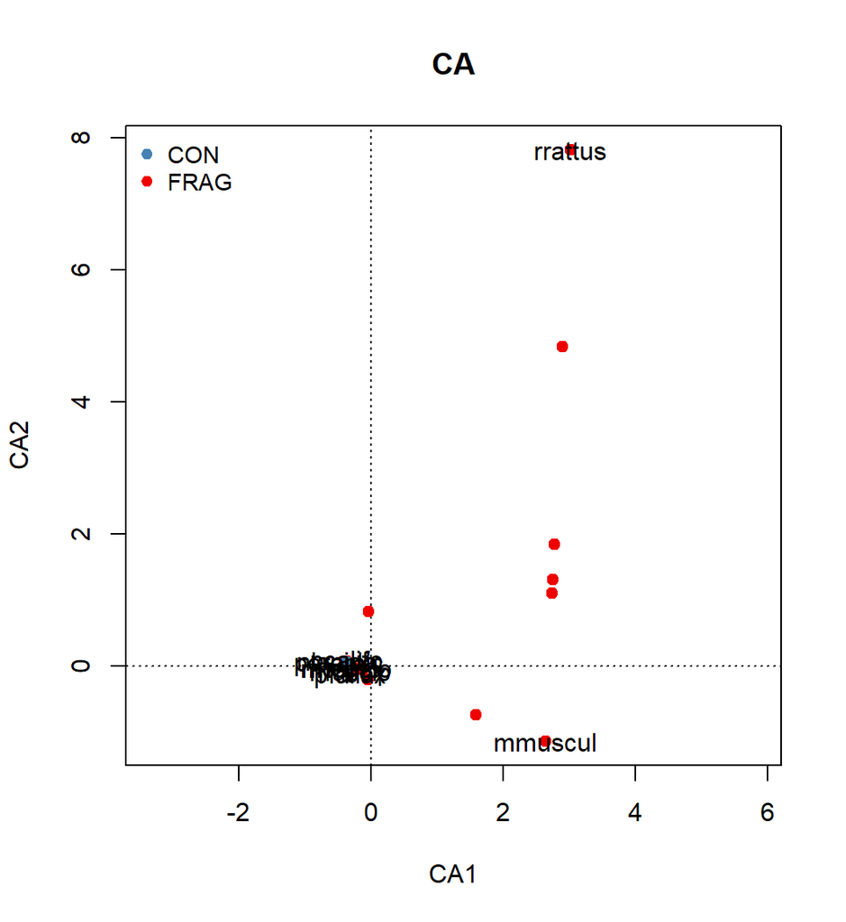

- На графике CA видно, что в нескольких местах больше *R.rattus* и *M.musculus*, чем ожидается (это интродуценты).
- В нескольких (других) сайтах сильно различаются наблюдаемые и ожидаемые численности “родных” видов.
- Сайты с нефрагментированной территории располагаются вперемешку с сайтами с фрагментированной территории.
- Эффект “дуги” (так называется “эффект подковы” для CA) не заметен, т.к. экологический градиент, видимо, оказался довольно коротким.

## Задание: Проведите корреспондентный анализ данных про птиц

- исчез ли эффект подковы?

## Решение

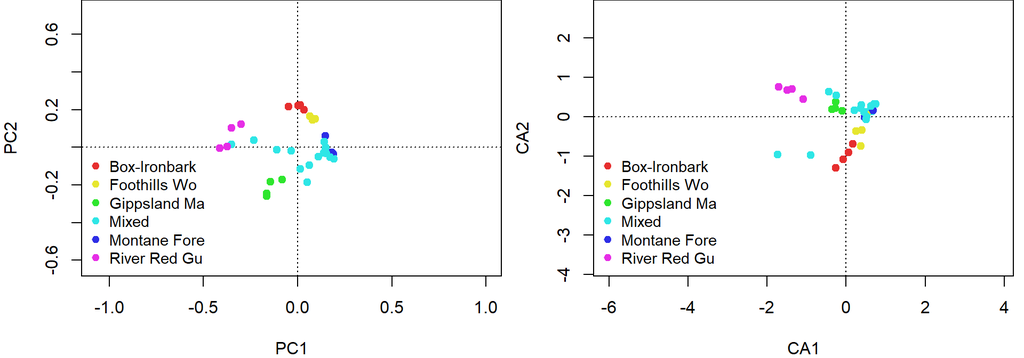

```r
bird_ca <- cca(birds[, -c(1, 2)])
op <- par(mfrow = c(1, 2), mar = c(4, 4, 0, 0.5))
col_ord_plot(ord = bird_h_pca, colfac = factor(birds$habitat), leg.pos = "bottomleft",
    ncol = 1, display.labs = FALSE)
col_ord_plot(ord = bird_ca, colfac = factor(birds$habitat), leg.pos = "bottomleft",
    ncol = 1, display.labs = FALSE)
par(op)
```

- Остался “эффект дуги” (так называется “эффект подковы” для корреспондентного анализа)

## Take home messages

- Анализ главных компонент
  - При анализе счетных признаков трансформация данных нужна, чтобы избежать “эффекта подковы”
- Корреспондентный анализ
  - придуман для анализа таблиц сопряженности
  - использует расстояние хи-квадрат
  - собственные числа отражают хи-квадрат, объясненный осями (степень зависимости столбцов и строк)

## Дополнительные ресурсы

- Borcard, D., Gillet, F., Legendre, P., 2011. Numerical ecology with R. Springer.
- Legendre, P., Legendre, L., 2012. Numerical ecology. Elsevier.
- Oksanen, J., 2011. Multivariate analysis of ecological communities in R: vegan tutorial. R package version 2–0.
- The Ordination Web Page URL http://ordination.okstate.edu/ (accessed 10.21.13).
- Quinn, G.G.P., Keough, M.J., 2002. Experimental design and data analysis for biologists. Cambridge University Press.
- Zuur, A.F., Ieno, E.N., Smith, G.M., 2007. Analysing ecological data. Springer.